# 1. Collect the 200 random samples and check the test of normality. Define statistically the samples are normally distributed or not.

```python
# to check normality we are going to use Kolmogorov-Smirnov's test
#data set
import random
dataset = [random.randint(11,159) for i in range(200)]
```

```python
#dataset
from scipy.stats import kstest
stats, pValue = kstest(dataset,'uniform')
print(f'Dataset: {dataset}')
print(f'stats: {stats}, pValue: {pValue}')
if pValue > .05: print("Dataset is distributed normally")
else : print("Dataset is not distributed normally")
```

```
Dataset: [61, 26, 133, 66, 63, 110, 53, 117, 146, 94, 130, 132, 54, 67, 149, 57, 79, 98, 64, 150, 117, 115, 70, 95, 101, 97, 79, 131, 147, 130, 101, 151, 19, 136, 54, 47, 112, 15, 31, 32, 107, 113, 111, 16, 52, 21, 140, 42, 61, 87, 41, 11, 51, 38, 92, 23, 102, 79, 21, 68, 121, 73, 117, 26, 100, 48, …
stats: 1.0, pValue: 0.0
Dataset is not distributed normally
```

[figure not shown]

# 2. Collect the 20 random samples and check the test of normality. Define statistically the samples are normally distributed or not.

```python
# to check normality we are going to use shapiro's test
#data set
import random
dataset = [random.randint(11,159) for i in range(20)]
```

```python
from scipy.stats import shapiro
stats, pValue = shapiro(dataset)
print(f'Dataset: {dataset}')
print(f'stats: {stats}, pValue: {pValue}')
if pValue > .05: print("Dataset is distributed normally")
else : print("Dataset is not distributed normally")
```

```
Dataset: [106, 128, 131, 79, 52, 49, 123, 54, 12, 117, 125, 50, 46, 153, 12, 158, 104, 56, 21, 124]
stats: 0.9190667271614075, pValue: 0.09507135301828384
Dataset is distributed normally
```

```python
# Ref: http://www.real-statistics.com/tests-normality-and-symmetry/statistical-tests-normality-symmetry/shapiro-wilk-test/
```

[figure not shown]

# 3. A professor wants to know if her introductory statistics class has a good grasp of basic math. Six students are chosen at random from the class and given a math proficiency test. The professor wants the class to be able to score above 70 on the test. The six students get scores of 62, 92, 75, 68, 83, and 95. Can the professor have 90 percent confidence that the mean score for the class on the test would be above 70?

## [T-Critical Value- 1.71, One Tail, Reject]

[figure not shown]

```python
#data set
sample = [62, 92, 75, 68, 83, 95]
n = len(sample)
#H0
mu = 70
c = 90
alpha = 10
#one tailed t test
```

```python
from scipy.stats import ttest_1samp
stats, pValue = ttest_1samp(sample,mu)
print(f'stats: {stats}, pValue: {pValue}')
if pValue > .10: print("Rejecting Null hypothesis")
else : print("Fail to reject Null hypothesis")
```

```
stats: 1.7053136360191492, pValue: 0.14885362711300268
Rejecting Null hypothesis
```

# 4. A Little League baseball coach wants to know if his team is representative of other teams in scoring runs. Nationally, the average number of runs scored by a Little League team in a game is 5.7. He chooses five games at random in which his team scored 5 , 9, 4, 11, and 8 runs. Is it likely that his team's scores could have come from the national distribution? Assume an alpha level of 0.05. [T-Critical Value- 1.32, Two Tail, Accept]

[figure not shown]

```python
#data set
mu = 5.7
sample = [5 , 9, 4, 11, 8]
alpha = 0.05
```

```python
from scipy.stats import ttest_1samp
stats, pValue = ttest_1samp(sample,mu)
print(f'stats: {stats}, pValue: {pValue}')
if pValue == alpha: print("Rejecting Null hypothesis")
else : print("Fail to reject Null hypothesis")
```

```
stats: 1.3194558937007659, pValue: 0.257472234280299
Fail to reject Null hypothesis
```

# 5. Perform Two Sample T-Test.

[figure not shown]

```python
#data set
x = [18,15,18,16,17,15,14,14,14,15,15,14,15,14,22,18,21,21,10,10,11]
y = [24,27,27,25,31,35,24,19,29,23,27,20,22,18,20,31,32,31,32,24,25]
alpha = 0.05
```

```python
from scipy.stats import ttest_ind
ststs ,pValue = ttest_ind(x,y)
print(f'stats: {stats}, pValue: {pValue}')
if pValue < alpha: print("Rejecting Null hypothesis")
else : print("Fail to reject Null hypothesis")
```

```
stats: 1.3194558937007659, pValue: 4.39031757544882e-10
Rejecting Null hypothesis
```

# 6. Create data set by entering the instances from user. Create two samples of ML subject Marks and Attendance Marks of 25 students. After creating stud.csv upload in python and perform Two Sample [Independent] Test.

[figure not shown]

```python
#creating file
import random
MLmarks = [random.randint(0,100) for i in range(25)]
Attendance = [random.randint(0,31) for i in range(25)]

file = open('studa.csv','a')
file.write('x,y\n')
for i in range(len(MLmarks)):
    file.writelines(f'{MLmarks[i]},{Attendance[i]}\n')
file.close()
```

```python
#dataset
import pandas as pd
dataset = pd.read_csv('studa.csv')
alpha = 0.05
```

```python
from scipy.stats import ttest_ind
ststs, pValue = ttest_ind(dataset['x'],dataset['y'])
print(f'stats: {stats}, pValue: {pValue}')
if pValue < alpha: print("Rejecting Null hypothesis")
else : print("Fail to reject Null hypothesis")
```

```
stats: 1.3194558937007659, pValue: 2.931405159319573e-07
Rejecting Null hypothesis
```

# 7. Forty-four sixth graders were randomly selected from a school district. Then, they were divided into 22 matched pairs, each pair having equal IQ's. One member of each pair was randomly selected to receive special training. Then, all of the students were given an IQ test. Test results are summarized below.

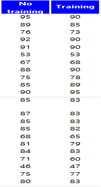

[figure not shown]

```python
#data set
x1 = [95,89,76,92,91,53,67,88,75,85,90,85,87,85,85,68,81,84,71,46,75,80]
x2 = [90,85,73,90,90,53,68,90,78,89,95,83,83,83,82,65,79,83,60,47,77,83]
alpha = 0.05
```

```python
from scipy.stats import ttest_rel
ststs, pValue = ttest_rel(x1,x2)
print(f'stats: {stats}, pValue: {pValue}')
if pValue < alpha: print("Rejecting Null hypothesis")
else : print("Fail to reject Null hypothesis")
```

```
stats: 1.3194558937007659, pValue: 0.20497954337471327
Fail to reject Null hypothesis
```

# 8. Perform paired t test.

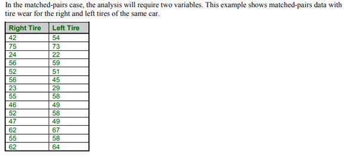

[figure not shown]

```python
#data set
x1 = [42,75,24,56,52,56,23,55,46,52,47,62,55,62]
x2 = [54,73,22,59,51,45,29,58,49,58,49,67,58,64]
alpha = 0.05
```

```python
from scipy.stats import ttest_rel
ststs, pValue = ttest_rel(x1,x2)
print(f'stats: {stats}, pValue: {pValue}')
if pValue < alpha: print("Rejecting Null hypothesis")
else : print("Fail to reject Null hypothesis")
```

```
stats: 1.3194558937007659, pValue: 0.1618240749558048
Fail to reject Null hypothesis
```

# 9. Let us assume a population of students in a school who appeared for a class test. The mean score in the test is 75 and the standard deviation is 15. Determine the z-test score of David who scored 90 in the test.

[figure not shown]

# 10. Let us take the example of 30 students who were selected as a part of a sample team to be surveyed to see how many pencils were being used in a week. Determine the z-test score for the 3rd student of based on the given responses: 3, 2, 5, 6, 4, 7, 4, 3, 3, 8, 3, 1, 3, 6, 5, 2, 4, 3, 6, 4, 5, 2, 2, 4, 4, 2, 8, 3, 6, 7.

[figure not shown]

```python
#data set
dataset = [3, 2, 5, 6, 4, 7, 4, 3, 3, 8, 3, 1, 3, 6, 5, 2, 4, 3, 6, 4, 5, 2, 2, 4, 4, 2, 8, 3, 6, 7]
x = dataset[3-1]
```

```python
import statistics
from statsmodels.stats import weightstats
ststs, pValue = weightstats.ztest(dataset,None,statistics.mean(dataset))
print(f'stats: {stats}, pValue: {pValue}')
if pValue >= 0.05: print("Fail to reject Null hypothesis")
else : print("Rejecting Null hypothesis")
```

```
stats: 1.3194558937007659, pValue: 1.0
Fail to reject Null hypothesis
```

# 11. The amount of a certain trace element in blood is known to vary with a standard deviation of 14.1 ppm (parts per million) for male blood donors and 9.5 ppm for female donors. Random samples of 75 male and 50 female donors yield concentration means of 28 and 33 ppm, respectively. What is the likelihood that the population means of concentrations of the element are the same for men and women?

[figure not shown]

```python
#data set
MaleSD = 14.1
FemaleSD = 9.5
MaleN = 75
FemaleN = 50
MaleMean = 28
FemaleMean = 33
```

```python
import numpy as np
zTest = (MaleMean-FemaleMean)/np.sqrt((MaleSD**2/MaleN)+(FemaleSD**2/FemaleN))
print(f'zTest = {zTest}')
```

```
zTest = -2.368684181472862
```

# 12. The following data is given Calculate the Anova Coefficient.

| Types of Animals | Number of animals | Average Domestic animals | Standard Deviation |
| --- | --- | --- | --- |
| Dogs | 5 | 12 | 2 |
| Cats | 5 | 16 | 1 |
| Hamsters | 5 | 20 | 4 |

[figure not shown]

```python
#data set
import pandas as pd
df = pd.read_csv('p12 excel to csv.csv')
```

```python
import scipy.stats as stats
stats,fvalue=stats.f_oneway(df['Type']=="Dogs",df['Type']=="Cats",df['Type']=="Hamsters")
print(f'stats: {stats}, fvalue: {fvalue}')
if fvalue < 0.05: print("Fail to reject Null hypothesis")
else : print("Rejecting Null hypothesis")
```

[output not shown]

# 13. For interpretation purposes, we refer to the differences in weights as weight losses and the observed weight losses are shown below.

| Low Calorie | Low Fat | Low Carbohydrate | Control |
| --- | --- | --- | --- |
| 8 | 2 | 3 | 2 |
| 9 | 4 | 5 | 2 |
| 6 | 3 | 4 | -1 |
| 7 | 5 | 2 | 0 |
| 3 | 1 | 3 | 3 |

# Is there a statistically significant difference in the mean weight loss among the four diets? We will run the ANOVA using the five-step approach.

[figure not shown]

```python
#data set
import pandas as pd
df=pd.read_csv("practical13.csv")
```

```python
import scipy.stats as stats
stats,fvalue=stats.f_oneway(df['Calorie'],df['Fat'],df['Carbohydrate'],df['Control'])
print(f'stats: {stats}, fvalue: {fvalue}')
if fvalue < 0.05: print("Rejecting Null hypothesis")
else : print("Fail to reject Null hypothesis")
```

[output not shown]